|  | Instituto Federal de São Paulo (IFSP) [Campus Bragança Paulista/SP](https://bra.ifsp.edu.br) **Análise e Desenvolvimento de Sistemas (ADS)** **Profa. Ana Paula Müller Giancoli** paulagiancoli@ifsp.edu… | **2o. módulo** |
| --- | --- | --- |

# Linguagem de Programação II (LP2I2)

## LISTA DE EXERCÍCIOS - LISTA06

### Desenvolver os exercícios na linguagem de programação Python.

##### Utilize o pyCharm para resolver, ou JupyterLab, ou Jupyter Notebook ou ainda, uma IDE que você se adapte melhor.

#### Questão 1. Faça um programa que leia um arquivo texto contendo uma lista de endereços IP e gere um outro arquivo, contendo um relatório dos endereços IP válidos e inválidos. O arquivo de entrada possui o seguinte formato:

200.135.80.9  
192.168.1.1  
8.35.67.74  
257.32.4.5  
85.345.1.2  
1.2.3.4  
9.8.234.5  
192.168.0.256

#### Questão 2.A ACME Inc., uma empresa de 500 funcionários, está tendo problemas de espaço em disco no seu servidor de arquivos. Para tentar resolver este problema, o Administrador de Rede precisa saber qual o espaço ocupado pelos usuários, e identificar os usuários com maior espaço ocupado. Através de um programa, baixado da Internet, ele conseguiu gerar o seguinte arquivo, chamado "usuarios.txt":

alexandre 456123789  
anderson 1245698456  
antonio 123456456  
carlos 91257581  
cesar 987458  
rosemary 789456125

- Neste arquivo, o nome do usuário possui 15 caracteres. A partir deste arquivo, você deve criar um programa que gere um relatório, chamado "relatório.txt", no seguinte formato:

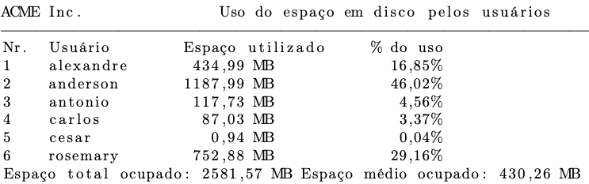

- O arquivo de entrada deve ser lido uma única vez, e os dados armazenados em memória, caso sejam necessários, de forma a agilizar a execução do programa. A conversão da espaço ocupado em disco, de bytes para megabytes deverá ser feita através de uma função separada, que será chamada pelo programa principal. O cálculo do percentual de uso também deverá ser feito através de uma função, que será chamada pelo programa principal.

#### Questão 3. Recriar o jogo da forca. Utilize sua criatividade, arquivos, funções, módulos, etc.

### Referências

- Esta lista de exercícios foi elaborada a partir do conteúdo disponibilizado nos **Livros de Lógica de Programação**.
- Consulte os livros disponíveis no link da Biblioteca indicado na **LP2I2_Aula01_InstrucoesIniciais**.

### Perguntas

- Esclareça suas eventuais dúvidas durante as aulas.
- Ou pelo *E-mail*: paulagiancoli@ifsp.edu.br.
- Ou pelo *Fórum* do componente curricular.

*ADS - Python versão 3.7 - 2o. módulo*.  
Modelo e formato elaborado por profa. Ana Paula Müller Giancoli - BSD 2-Clause License. - Julho.2020.